# analyze

```r
library(tidyverse)
library(lubridate)
library(memoise)
```

```r
generic.ci_ <- function(x, n = 5000, seed = 1) {
  set.seed(seed)
  lenx = length(x)

  structure(
    quantile(
      replicate(n, mean(x[sample.int(lenx, replace = TRUE)])),
      c(0.025, 0.975)),
    names=c("ci.l","ci.u"))
}

generic.ci <- memoise(generic.ci_)
```

# read in data

```r
results.dir = "production-results/"
assignments = read_csv(paste0(results.dir, "assignments.csv")) %>%
  mutate(accept.time = ymd_hms(accept.time),
         submit.time = ymd_hms(submit.time),
         duration = difftime(submit.time, accept.time, units = "mins"))
responses = read_csv(paste0(results.dir, "responses.csv"),
                     col_types = cols(string = col_character()))
```

```r
regexes = c('3a' = 'aaa+',
            'zip-code' = '[0123456789]{5}',
            'consonants-only' = '[bcdfghjklmnpqrstvwxyzBCDFGHJKLMNPQRSTVWXYZ]*',
            'delimiters' = "\\[.*\\]")

example.matches = function(example, rx) {
  res = regexpr(pattern = rx, text = example)
  # make sure we match and that the *entire* string is what matches, not a substring
  res > 0 & attr(res, "match.length") == nchar(example)
}
# example.correct(example = 'aaa', rx = 'aaa+')
# example.correct(example = 'baaa', rx = 'aaa+')
# example.correct(example = 'aaaa', rx = 'aaa+')

responses = responses %>%
  mutate(rx = regexes[rule.id])

responses_match = apply(responses[,c('string','rx')],
      1,
      function(e) { example.matches(example = e['string'], rx = e['rx']) })

responses = mutate(responses,
                   match = responses_match,
                   correct = !xor(polarity == 'positive', match)) %>%
  select(-rx, -rule.desc) # hide these cause they're verbose

# # testing
# View(responses %>% select(rule.id, polarity, string, correct, match) %>% arrange(rule.id, polarity))
```

# user experience

## how long does the task take?

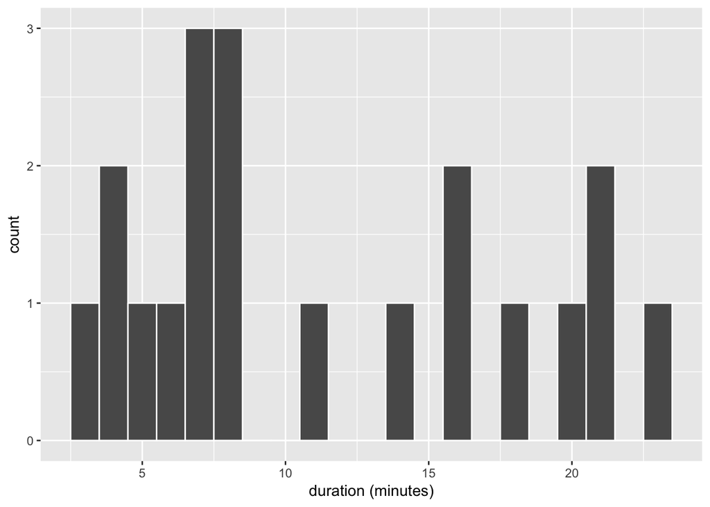

```r
qplot(data = assignments,
      x = as.numeric(duration),
      binwidth = 1,
      color = I('white')) +
  xlab("duration (minutes)")
```

## what did people think was a fair payment?

```r
fair.pay = assignments$fair_pay %>% as.numeric %>% na.omit
```

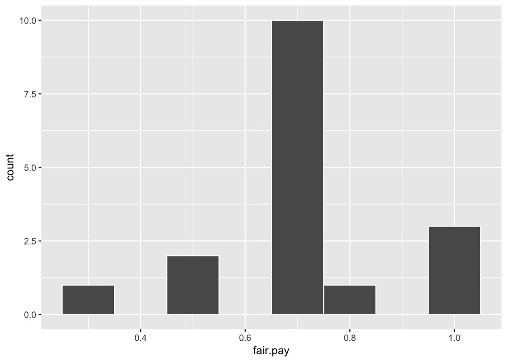

```r
fair.pay = fair.pay[fair.pay < 5]
qplot(x = fair.pay,
      binwidth = 0.1,
      color = I('white')
      )
```

# research

## how many examples do people give?

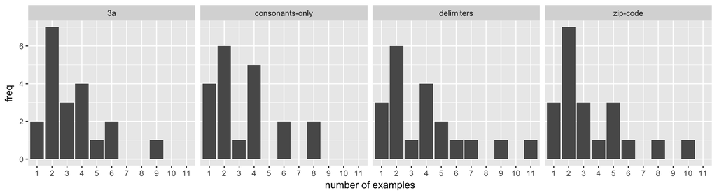

```r
e.agg = responses %>% group_by(worker.id, rule.id) %>%
  summarise(num.examples = n()) %>%
  group_by(worker.id, rule.id, num.examples) %>%
  summarise(freq = n())

xmin = 1 #min(e.agg$num.examples)
xmax = max(e.agg$num.examples)

e.agg$num.examples.fct = factor(e.agg$num.examples, levels = as.character(xmin:xmax))

ggplot(data = e.agg) +
  facet_grid(. ~ rule.id) +
  geom_bar(mapping = aes(x = num.examples.fct, y = freq), stat = 'identity') +
  scale_x_discrete(breaks = as.character(xmin:xmax), drop = FALSE, name = 'number of examples')
```

exactly 2 seems to be common

q: in cases of 2 examples, is it one positive and one negative?

## how many positive examples versus negative examples?

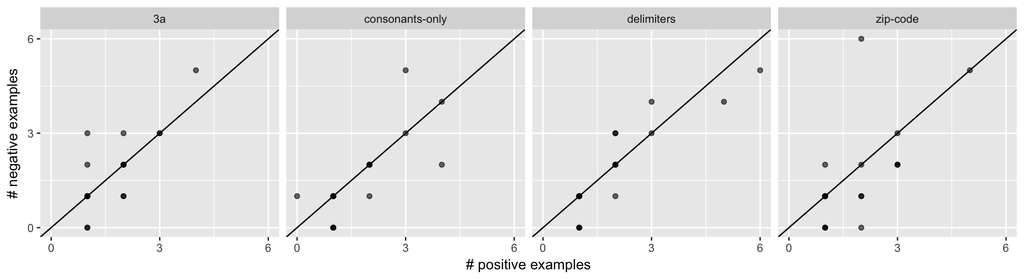

```r
e.agg = responses %>% group_by(worker.id, rule.id) %>%
  summarise(num.pos = sum(polarity == "positive"),
            num.neg = sum(polarity == "negative"))

qplot(data = e.agg,
      facets = . ~ rule.id,
      x = num.pos,
      y = num.neg, alpha = I(0.6)) +
  geom_abline() +
  scale_x_continuous(name = '# positive examples', breaks = c(0, 3, 6), limits = c(0, 6)) +
  scale_y_continuous(name = '# negative examples', breaks = c(0, 3, 6), limits = c(0, 6))
```

## how related are the examples in edit distance?

```r
cluster.examples = function(strings, distance.threshold = 2) {
  distance.matrix = adist(strings)

  # for each string, figure out which other strings it's similar to
  # (i.e., has edit distance less than the threshold)
  similarities = apply(distance.matrix,
        1,# by row
        function(row) {
          which(row <= distance.threshold)
        })
  clusters = list()
  # print(similarities)

  # make the clusters
  Map(1:length(strings),
      f = function(i) {
        # j is the index of the previously created cluster that can contain this string
        j = Position(x = clusters,
                     f = function(cluster) { i %in% cluster })

        if (is.na(j)) {
          clusters[[length(clusters) + 1]] <<- similarities[[i]]
        } else {
          clusters[[j]] <<- union(clusters[[j]], similarities[[i]])
        }
      })

  Map(clusters,
      f = function(indices) { strings[indices] })
}

# # testing
# strings = c("01234", "012a4", "62804", "628041", "y6280", "0123", "280", "a280b")
# #strings = c('aaa','aa','aaab','baaaab','bbaaabb')
# ## strings = c("94301", "40510", "33333", "r2349", "asdfa", "3621", "834920")
# cluster.examples(strings)
```

```r
responses.clustered = responses %>%
  group_by(worker.id, rule.id) %>%
  summarise(num.examples = n(),
            num.clusters = length(cluster.examples(string)))

responses.clustered %>% group_by(worker.id) %>% summarise(mean_num.clusters = mean(num.clusters))
```

```
## # A tibble: 20 × 2
##    worker.id mean_num.clusters
##        <chr>             <dbl>
## 1    1b43720              3.50
## 2    1ec52d4              3.25
## 3    26e3c2f              7.75
## 4    311ee08              3.25
## 5    45dc6aa              2.75
## 6    4ba0325              3.75
## 7    57b9205              1.00
## 8    59d56e8              2.00
## 9    613ec1c              2.25
## 10   682f9ab              6.25
## 11   71ae71c              2.00
## 12   827dce1              1.25
## 13   8b16511              4.00
## 14   97bb05e              2.25
## 15   aacaf2c              3.75
## 16   bcbceaf              1.75
## 17   d4ec1a2              2.00
## 18   d55958e              1.00
## 19   ebfa63a              4.00
## 20   f164eee              1.75
```

```r
mean.num.clusters = mean(responses.clustered$num.clusters)
mean.num.clusters
```

```
## [1] 2.975
```

TODO: do there tend to be more negative examples within a cluster? (i think people might come up with one example and then demonstrate various ways it can be perturbed to be a non-example)

comparison to permutation test: sample random participants by sampling from pool of all participants’ responses (note that this is sampling *without* replacement, as people wouldn’t give the same example twice)

```r
sample.bootstrap.subject = function(worker.id, rule.id) {
  # get examples given by all participants for this rule
  ## written in non-dplyr syntax because i think it might be faster?
  pool = responses[responses$rule.id == rule.id,]
  pool.pos = pool[pool$polarity == 'positive',]$string
  pool.neg = pool[pool$polarity == 'negative',]$string

  # get this worker's examples
  this = pool[pool$worker.id == worker.id,]

  num.pos = sum(this$polarity == 'positive')
  num.neg = sum(this$polarity == 'negative')

  syn.pos = sample(x = pool.pos, size = num.pos, replace = FALSE)
  syn.neg = sample(x = pool.neg, size = num.neg, replace = FALSE)

  c(num.clusters = length(cluster.examples(c(syn.pos, syn.neg))))
}

workers.and.rules = responses.clustered[,c('worker.id', 'rule.id')]

clusters.bootstrap = function() {
  num.clusters = apply(workers.and.rules,
                       1,
                       function(e) {
                         sample.bootstrap.subject(e['worker.id'], e['rule.id'])
                       })

  mean(num.clusters)
}

# a little slow because my clustering function is not vectorized
time = system.time(bootstrap.samples <- replicate(5000, clusters.bootstrap()))

writeLines(paste0("elapsed seconds: ", round(unname(time['elapsed']), 1)))
```

```
## elapsed seconds: 261.3
```

```r
writeLines(paste0('95% ci for bootstrap: ', paste0(quantile(bootstrap.samples, c(0.025, 0.0975)), collapse = " - ")))
```

```
## 95% ci for bootstrap: 3.15 - 3.1875
```

```r
# one-tailed test: how many bootstrap samples have a mean
# number of clusters less than the observed sample?
sum(bootstrap.samples < mean.num.clusters) / length(bootstrap.samples)
```

```
## [1] 0
```

## how many mistakes do people make? (e.g., positive examples that don’t actually match or negative examples that do match)

by stimulus:

```r
responses %>%
  group_by(rule.id) %>%
  summarise(error.rate = sum(!correct) / n())
```

```
## # A tibble: 4 × 2
##           rule.id error.rate
##             <chr>      <dbl>
## 1              3a 0.10447761
## 2 consonants-only 0.02985075
## 3      delimiters 0.02597403
## 4        zip-code 0.11594203
```

inspecting errors:

```r
responses %>% filter(!correct) %>% select(rule.id, worker.id, string, polarity, match, correct) %>% arrange(rule.id)
```

```
## # A tibble: 19 × 6
##            rule.id worker.id          string polarity match correct
##              <chr>     <chr>           <chr>    <chr> <lgl>   <lgl>
## 1               3a   613ec1c         aaajihg positive FALSE   FALSE
## 2               3a   4ba0325    a123aa123415 positive FALSE   FALSE
## 3               3a   4ba0325       xczzadtaa positive FALSE   FALSE
## 4               3a   f164eee             AAA positive FALSE   FALSE
## 5               3a   f164eee           AaAaA positive FALSE   FALSE
## 6               3a   97bb05e     aaaiinasins positive FALSE   FALSE
## 7               3a   71ae71c        a33_35_a positive FALSE   FALSE
## 8  consonants-only   311ee08             abc positive FALSE   FALSE
## 9  consonants-only   311ee08           atfdc positive FALSE   FALSE
## 10      delimiters   f164eee        {Fsje2n} positive FALSE   FALSE
## 11      delimiters   59d56e8 aaafffsdfsdfaaa positive FALSE   FALSE
## 12        zip-code   613ec1c           00000 negative  TRUE   FALSE
## 13        zip-code   4ba0325           11111 negative  TRUE   FALSE
## 14        zip-code   4ba0325           22222 negative  TRUE   FALSE
## 15        zip-code   97bb05e           00000 negative  TRUE   FALSE
## 16        zip-code   311ee08           00000 negative  TRUE   FALSE
## 17        zip-code   1ec52d4           00000 negative  TRUE   FALSE
## 18        zip-code   1ec52d4           99999 negative  TRUE   FALSE
## 19        zip-code   1ec52d4           00001 negative  TRUE   FALSE
```

issues - 3a: ambiguity about lower versus upper case. also, it needs to be clearer that the string contains *only* a’s. - zip-code: the zip code framing might be too semantic. people might be thinking “give examples of *real* zip codes”

by person:

```r
responses %>%
  group_by(worker.id) %>%
  summarise(error.rate = sum(!correct) / n()) %>%
  arrange(desc(error.rate))
```

```
## # A tibble: 20 × 2
##    worker.id error.rate
##        <chr>      <dbl>
## 1    f164eee  0.3333333
## 2    4ba0325  0.2500000
## 3    613ec1c  0.2222222
## 4    97bb05e  0.2222222
## 5    1ec52d4  0.1666667
## 6    59d56e8  0.1250000
## 7    71ae71c  0.1250000
## 8    311ee08  0.1034483
## 9    1b43720  0.0000000
## 10   26e3c2f  0.0000000
## 11   45dc6aa  0.0000000
## 12   57b9205  0.0000000
## 13   682f9ab  0.0000000
## 14   827dce1  0.0000000
## 15   8b16511  0.0000000
## 16   aacaf2c  0.0000000
## 17   bcbceaf  0.0000000
## 18   d4ec1a2  0.0000000
## 19   d55958e  0.0000000
## 20   ebfa63a  0.0000000
```

## how long are the examples that people give?

by stimulus:

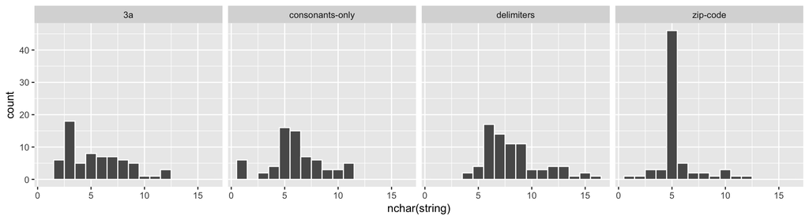

```r
qplot(data = responses,
      facets = . ~ rule.id,
      x = nchar(string),
      binwidth = 1,
      color = I('white'))
```

by person:

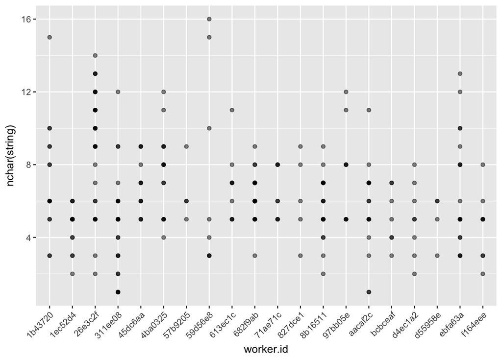

```r
qplot(data = responses,
      x = worker.id,
      y = nchar(string), alpha = I(0.5)) +
  theme(axis.text.x = element_text(angle = 45, hjust = 1))
```

## do people give examples in particular orders? e.g., shorter ones first or positive ones first?

### length

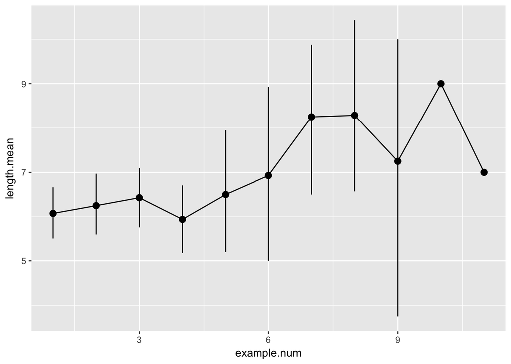

```r
e = responses %>%
  transform(len = nchar(string)) %>%
  group_by(example.num) %>%
  summarise(length.mean = mean(len),
            length.cl = generic.ci(len)['ci.l'],
            length.cu = generic.ci(len)['ci.u']) %>%
  ungroup

qplot(data = e,
      x = example.num,
      y = length.mean,
      ymin = length.cl,
      ymax = length.cu,
      geom = c('pointrange','line'))
```

note: confidence intervals for last two points are actually huge (very few unique data values, e.g., 1)

### polarity

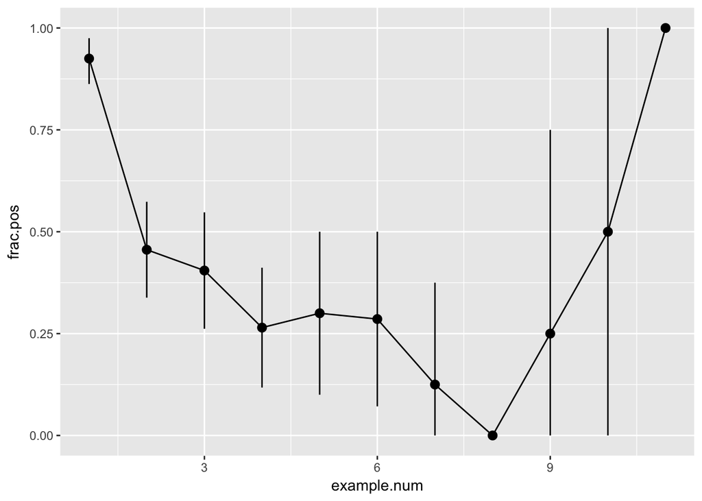

```r
e = responses %>%
        group_by(example.num) %>%
        summarise(frac.pos = sum(polarity == 'positive') / n(),
                  ci.l = generic.ci(polarity == 'positive')['ci.l'],
                  ci.u = generic.ci(polarity == 'positive')['ci.u'])

qplot(data = e,
      x = example.num,
      y = frac.pos,
      ymin = ci.l,
      ymax = ci.u,
      geom = c('pointrange','line'))
```

interesting – first example tends to be positive

# TODO

- do positive examples tend to be followed by negative examples?
- do positive examples tend to be dissimilar from other positive examples? (but similar to a subset of negative examples) [metaphor – a positive example as a primary tentpole that supports a number of negative example tentpoles]